# Data Wrangling Part 2

### Welcome to SummeR of R at the Brandeis Library!

Margarita Corral

mcorral@brandeis.edu

[Make an appointment with Margarita!](https://calendar.library.brandeis.edu/appointment/8518)

Claire Pontbriand

cpontbriand@brandeis.edu

[Make an appointment with Claire!](https://calendar.library.brandeis.edu/appointments/scidata)

#### Data Wrangling Part 2: Combining Data Sets, stringr, and lubridate

## Combining Data Sets

We might need to merge data sets before running our analyses. Today we will learn some of the functions in the dplyr package that will help us combine data.

Check out the [Data Wrangling Cheat Sheet by RStudio](https://www.rstudio.com/wp-content/uploads/2015/02/data-wrangling-cheatsheet.pdf)

We start with loading the tidyverse (if you are new to the series you need to install the package first, delete the hashtag at line 33 to do that)

```r
#install.packages('tidyverse')
library(tidyverse)
```

There are several ways to combine data sets. We are going to focus on 3. frames.

**1. Inner Join()** This function matches pairs of observations whose keys (the variable that uniquely identifies an observation)are equal. inner_join() will exclude unmatched rows.

Let’s see an example. We download two data sets from the World Bank, one with GDP data and another one with life expectacy for a few countries.

```r
gdp<-read_csv("gdp.csv") #read in the dataframe
print(gdp)
```

```
## # A tibble: 4 x 2
##   Country          GDP
##   <chr>          <dbl>
## 1 Argentina     14398.
## 2 United States 59928.
## 3 Zimbabwe       1333.
## 4 Portugal      21291.
```

```r
LifeExpectancy<-read_csv("LifeExp.csv") #read in the dataframe
print(LifeExpectancy)
```

```
## # A tibble: 4 x 2
##   Country       LifeExp
##   <chr>           <dbl>
## 1 Argentina        76.7
## 2 United States    78.5
## 3 Bolivia          69.4
## 4 Portugal         81.1
```

```r
LifeExp_gdp <- inner_join(gdp, LifeExpectancy, by="Country")
print (LifeExp_gdp)
```

```
## # A tibble: 3 x 3
##   Country          GDP LifeExp
##   <chr>          <dbl>   <dbl>
## 1 Argentina     14398.    76.7
## 2 United States 59928.    78.5
## 3 Portugal      21291.    81.1
```

**2. Full Join()** What if we want to keep all observations? We can use full_join()

```r
LifeExp_gdp_all <- full_join(gdp, LifeExpectancy, by="Country")
print (LifeExp_gdp_all)
```

```
## # A tibble: 5 x 3
##   Country          GDP LifeExp
##   <chr>          <dbl>   <dbl>
## 1 Argentina     14398.    76.7
## 2 United States 59928.    78.5
## 3 Zimbabwe       1333.    NA
## 4 Portugal      21291.    81.1
## 5 Bolivia          NA     69.4
```

**3. Left Join()** Another function is left_join() that keeps all observations in the first data set

```r
LifeExp_gdp_left <- left_join(gdp, LifeExpectancy, by="Country")
print (LifeExp_gdp_left)
```

```
## # A tibble: 4 x 3
##   Country          GDP LifeExp
##   <chr>          <dbl>   <dbl>
## 1 Argentina     14398.    76.7
## 2 United States 59928.    78.5
## 3 Zimbabwe       1333.    NA
## 4 Portugal      21291.    81.1
```

### Working with Characters

Sometimes we need to work with character strings. The package stringr has many useful functions

We can use the c() function to store character vectors

```r
days<- c("Sunday", "Monday", "Tuesday", "Wednesday", "Thursday", "Friday", "Saturday")
days
```

```
## [1] "Sunday"    "Monday"    "Tuesday"   "Wednesday" "Thursday"  "Friday"
## [7] "Saturday"
```

or str_c()

```r
months<-str_c("January", "February", "March", "April", "May", "June", "July", "August", "September", "October", "November", "December")
months
```

```
## [1] "JanuaryFebruaryMarchAprilMayJuneJulyAugustSeptemberOctoberNovemberDecember"
```

Let’s separate them

```r
months<-str_c("January", "February", "March", "April", "May", "June", "July", "August", "September", "October", "November", "December", sep = ", ")
months
```

```
## [1] "January, February, March, April, May, June, July, August, September, October, November, December"
```

String Length

```r
str_length(days)
```

```
## [1] 6 6 7 9 8 6 8
```

```r
str_length(months)
```

```
## [1] 96
```

```r
str_length("banana")
```

```
## [1] 6
```

Subsetting Strings

```r
str_sub(days, 1,3) #str_sub(string, start = 1L, end = -1L)
```

```
## [1] "Sun" "Mon" "Tue" "Wed" "Thu" "Fri" "Sat"
```

Negative numbers will count backwards from the end

```r
str_sub(days, -3, -1)
```

```
## [1] "day" "day" "day" "day" "day" "day" "day"
```

Return a pattern

```r
str_subset(days, "m")
```

```
## character(0)
```

Mutating strings (str_to_lower, str_to_upper, str_to_title)

```r
days_lowercase<-str_to_lower(days)
days_lowercase
```

```
## [1] "sunday"    "monday"    "tuesday"   "wednesday" "thursday"  "friday"
## [7] "saturday"
```

Let’s try again!

```r
str_subset(days_lowercase, "m")
```

```
## [1] "monday"
```

Can you detect “cell” in a piece of text?

```r
?str_detect()
```

```r
str_detect("this is the text", "cell")
```

```
## [1] FALSE
```

```r
str_detect("this is the cell", "cell")
```

```
## [1] TRUE
```

Let’s use a data frame to see how these functions can be used

```r
nobel_winners <- readr::read_csv("https://raw.githubusercontent.com/rfordatascience/tidytuesday/master/data/2019/2019-05-14/nobel_winners.csv")
```

Who was motivated by “cell”? is it related to their category?

```r
cell<-nobel_winners %>% filter(str_detect(motivation, "cell"))
```

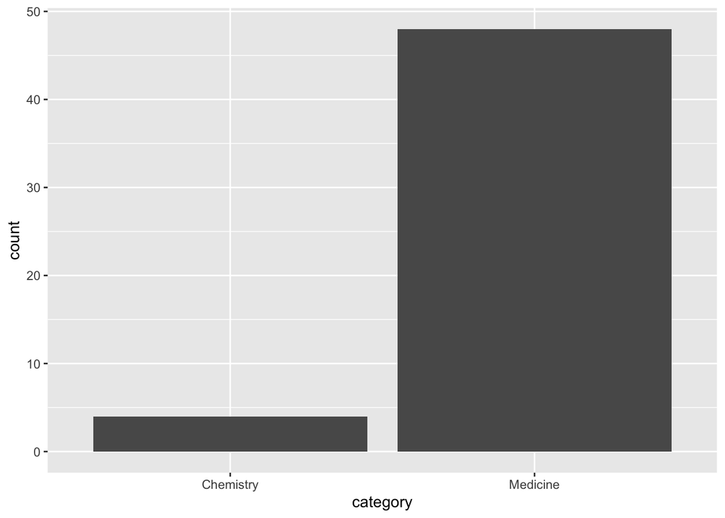

```r
ggplot(cell, aes(category))+
         geom_bar()
```